# Atividade_3_5_site_Mariana_Faitanin

Mariana Faitanin

23/05/2022

#Atividade final da disciplina Ciência colaborativa

ATIVIDADE 3

##Para iniciar as atividades, é necessário a instalação de alguns pacotes.

```r
require(tidyverse)
require(rgbif)
require(dplyr)
require(ggmap)
```

```r
require(maps)
require(mapdata)
require(ggplot2)
require(yaml)
```

###Com a função “occ_data” podemos realizar uma busca simplificada nos pontos de ocorrência da base de dados GBIF (Global Biodiversity Information Facility). Essa busca será realizadas através do nome ciêntífico e pelas ocorrências. ###Selecionamos a Melanoxylon brauna, uma espécie vegetal endêmica do Brasil pertencente a família fabaceae.

```r
# checar funcoes
?occ_data
```

```
## starting httpd help server ... done
```

```r
# baixar ocorrencias
brauna_gbif <- occ_data(scientificName = "melanoxylon brauna",
                      hasCoordinate = TRUE,
                      hasGeospatialIssue=FALSE)

# dimensoes
dim(brauna_gbif)
```

```r
dim(brauna_gbif$data)
```

```
## [1] 294 109
```

#Após 294 conferir o número de linhas e colunas do seu objeto, teremos que conferir o nome das colunas dentro desse dataset

```r
# checar campos
brauna_gbif$data %>% names
```

```
##   [1] "key"                           "scientificName"
##   [3] "decimalLatitude"               "decimalLongitude"
##   [5] "issues"                        "datasetKey"
##   [7] "publishingOrgKey"              "installationKey"
##   [9] "publishingCountry"             "protocol"
##  [11] "lastCrawled"                   "lastParsed"
##  [13] "crawlId"                       "hostingOrganizationKey"
##  [15] "basisOfRecord"                 "occurrenceStatus"
##  [17] "taxonKey"                      "kingdomKey"
##  [19] "phylumKey"                     "classKey"
##  [21] "orderKey"                      "familyKey"
##  [23] "genusKey"                      "speciesKey"
##  [25] "acceptedTaxonKey"              "acceptedScientificName"
##  [27] "kingdom"                       "phylum"
##  [29] "order"                         "family"
```

[output cut: 40 more lines]

```r
names(brauna_gbif)
```

```
## [1] "meta" "data"
```

#Aqui continuamos selecionando e validando algumas variáveis do banco de dados para essa e análises futuras. Por exemplo: coordenadas, localidade, nome da base de dados etc.

```r
brauna_gbif1 <- brauna_gbif$data %>%
  dplyr::select(scientificName, acceptedScientificName, decimalLatitude, decimalLongitude,
         issues, basisOfRecord, occurrenceStatus, rightsHolder,
         datasetName, recordedBy, locality,habitat,stateProvince)
```

#Temos variáveis, mas com a função distinct do pacote dplyr conseguimos avaliar quais dessas são únicas.

```r
brauna_gbif1 <- brauna_gbif1 %>%
  distinct()
```

#Note que das 294 variáveis iniciais restaram 274 ocorrências, isso acontece devido ao a quantidade de colunas iniciais que foram descartadas para essa tarefa. #ps:para ver esse resultado, basta olhar no environment

#Para identificar todos os valores únicos presente nos dados, vamos aplicar a função unique a cada coluna com um loop na função lapply.

```r
# checar niveis dos fatores
lapply(brauna_gbif1, unique)
```

```
## $scientificName
## [1] "Melanoxylon brauna Schott"  "Melanoxylon braunia Schott"
##
## $acceptedScientificName
## [1] "Melanoxylon brauna Schott"
##
## $decimalLatitude
##   [1] -19.615556 -20.599278 -21.367222 -19.835278 -21.380278 -19.467978
##   [7] -17.665767 -22.354444 -21.372222 -19.000000 -21.378889 -19.750833
##  [13] -17.139167 -10.354444 -18.076944 -17.809722 -21.358056 -13.030278
##  [19] -18.907778 -18.916185 -18.058611 -21.428056 -11.988056 -11.988060
##  [25] -12.973333 -22.677500 -14.333056 -19.150000 -22.677508 -15.297222
##  [31] -20.099444 -19.189722 -20.291944 -16.843333 -24.800417 -10.900000
##  [37] -19.002500 -19.890278 -13.688611 -22.650000 -22.666667 -10.126000
##  [43] -22.655556 -20.142222 -13.887500 -20.795555 -16.419167 -16.441667
```

[output cut: 596 more lines]

#A partir daqui faremos uma checagem mais detalhada e minuciosa dos nossos dados. Inicialmente, iremos validar as coordenadas geográficas. #ATEÇÃO:Para essa etapa sera necerrário a utilização dos pacotes “bcd” e “CoordinateCleaner”.

```r
library(bdc)
library(CoordinateCleaner)
# checar coordenadas válidas
check_pf <-
  bdc::bdc_coordinates_outOfRange(
    data = brauna_gbif1,
    lat = "decimalLatitude",
    lon = "decimalLongitude")
```

```
##
## bdc_coordinates_outOfRange:
## Flagged 0 records.
## One column was added to the database.
```

#O próximo passo será checar coordenadas válidas e próximas a capitais. A realização dessa etapa é importante e necessária, pois alguns pesquisadores quando não coleta a coordenada no dia do campo acaba colocando o coordenada “padrão” para o fragmento ou a coordenada do municipio.

```r
cl <- brauna_gbif1 %>%
  select(acceptedScientificName, decimalLatitude, decimalLongitude) %>%
  rename(decimallongitude = decimalLongitude,
         decimallatitude = decimalLatitude,
         scientificName = acceptedScientificName) %>%
  as_tibble() %>%
  mutate(val = cc_val(., value = "flagged"),
         sea = cc_sea(., value = "flagged"),
         capital = cc_cap(., value = "flagged"))
```

```
## Testing coordinate validity
```

```
## Flagged 0 records.
```

```
## Testing sea coordinates
```

```
## Flagged 2 records.
```

```
## Testing country capitals
```

```
## Flagged 2 records.
```

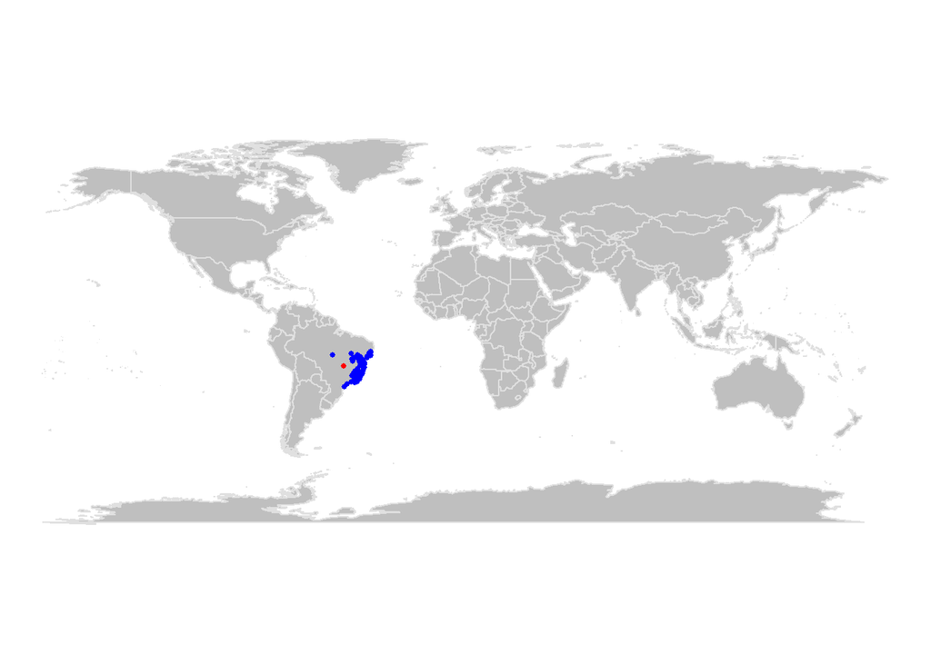

```r
# verificar coordenadas com flags

# capitais (padrão é um raio de 10km)
cl %>%
  rename(decimalLongitude = decimallongitude,
         decimalLatitude = decimallatitude) %>%
  bdc::bdc_quickmap(., col_to_map = "capital")
```

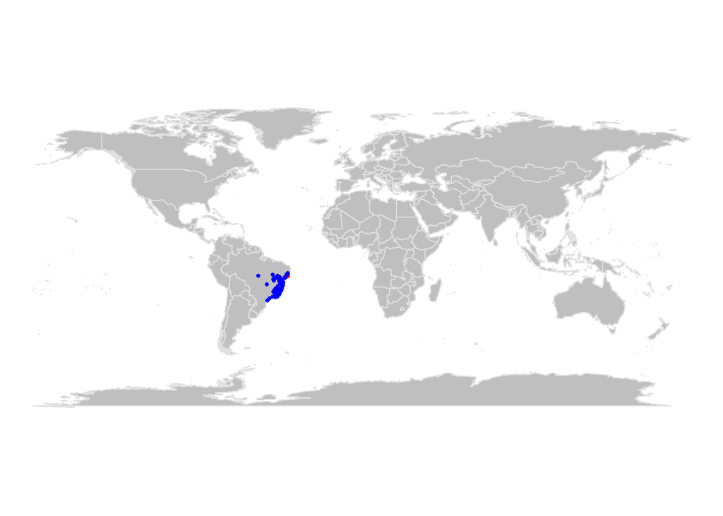

```r
cl %>%
  rename(decimalLongitude = decimallongitude,
         decimalLatitude = decimallatitude) %>%
  bdc::bdc_quickmap(., col_to_map = "sea")
```